# Preliminary Survey on Math Background (Answers)

ECON 306 — Fall 2022

## 1

#### Draw a graph of the following linear equation, $R=4-\frac{1}{2}W$. Plot $W$ on the vertical axis and $R$ on the horizontal axis.

First, we must recognize that to plot a function, the vertical axis variable ($W$) must be alone on one side of the equation. Here, we have the horizontal axis variable ($R$) alone. Thus, we must solve for $W$:
$$\begin{align*}R&=4-\frac{1}{2}W & &
\text{Original function}\\
R-4&=-\frac{1}{2}W & & \text{Subtract 4 from both sides}\\
8-2R&=W & & \text{Multiply both sides by }-2\\
\end{align*}$$

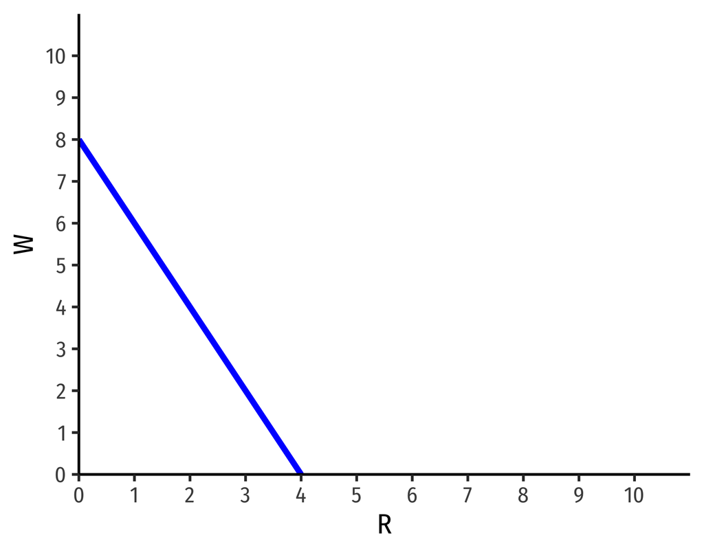

## 2

#### Draw a continuous function which begins at the origin, increases at a *decreasing* rate, reaches an inflection point, and then increases at an *increasing* rate. Show where each part of the function is concave or convex.

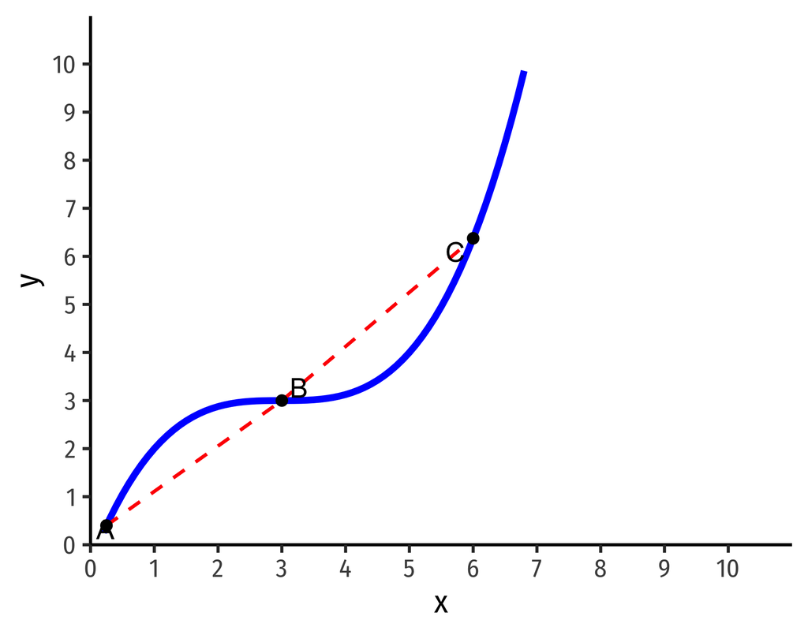

The function is **concave** from A to B, since a secant line between two points (red) lies *under* the function.

The inflection point is at B, since the curvature of the function switches from concave to convex.

## 3

#### Solve the system of equations for $x$ and $y$:

$$\begin{align*}
2x+y&=20\\
4x-3y&=10\\
\end{align*}$$

We can use either the substitution or elimination methods. Here, I use substitution. Pick one equation and isolate one variable. Here, I pick the first equation and isolate $x$ to one side:
$$\begin{align*}
2x+y&=20 & & \text{Original equation}\\
2x&=20-y & & \text{Subtracting } y \text{ from both sides}\\
x&=10-\frac{1}{2}y & & \text{Dividing both sides by 2}\\
\end{align*}$$

Now, substitute this in for $x$ in the other equation, and solve for $y$:

$$\begin{align*}
4(10-\frac{1}{2}y)-3y&=10 && \text{Substituting }
10-\frac{1}{2}y \text{ in for x}\\
40-2y-3y&=10 && \text{Distributing the 4}\\
-2y-3y&=-30 && \text{Subtracting 40 from both sides}\\
-5y&=-30 && \text{Simplifying }y \text{'s}\\
y&= 6 && \text{Dividing both sides by }-5\\
\end{align*}$$

Now, substitute this into the first equation.

$$\begin{align*}
2x+(6)&=20 && \text{Substituting in 6 for }y\\
2x&=14 && \text{Subtracting 6 from both sides}\\
x&=7 && Dividing both sides by 2\\ \end{align*}$$

Now to double check, pick an equation and substitute both $x$ and $y$ to make sure the equation is true.

$$\begin{align*}
2(7)+(6)&=20 && \text{Substituting in 7 for }x \text{and 6
for }y\\
14+6&=20 && \text{Simplifying}\\ \end{align*}$$

We’ll verify again by checking the other equation is true.

$$\begin{align*}
4(7)-3(6)&=10 && \text{Substituting in 7 for }x \text{and 6
for }y\\
28-18&=10 && \text{Simplifying}\\ \end{align*}$$

## 4

#### *Simplify* the following equation:

$$Z=\frac{0.5X^{-0.5}
Y^{0.5}}{0.5X^{0.5}Y^{-0.5}}$$

By the exponent rule for division $\left(\frac{X^a}{X^b}=X^{a-b}\right)$ for $X$ and for $Y$:

$$\begin{align*}
Z&=\frac{0.5}{0.5}X^{[-0.5-0.5]}Y^{[0.5-(-0.5)]}\\
Z&=(1)X^{-1}Y^{1}\\
\end{align*}$$

By the rule for negative exponents ($X^{-a}=\frac{1}{X^a}$):

$$\begin{align*}
Z&=\frac{Y^1}{X^1}\\
Z&=\frac{Y}{X}\\
\end{align*}$$

## 5

#### For the function $f(x) = 3x^2+2x-7$:

### a.

#### Take the derivative of $f(x)$, i.e. $f'(x)$.

Use the power functions rule: Where $f(x) = ax^n$, $f'(x) = (an)x^{(n-1)}$. So for $f(x) = 3x^2+2x-7$, the derivative is $(2*3)x^{(2-1)}+(1*2)x^{(1-1)}$ or $6x+2$.

### b.

#### In English, describe what the derivative of $f(x)$ means.

The function $f'(x)$ is the derivative of function $f(x)$, and it represents the rate of change (i.e. the slope) at every point defined on the function $f(x)$.

### c.

#### Evaluate $f'(4)$. In English, describe what this means.

Simply plug the value $x=4$ into the derivative function $f'(4)$: $6(4)+2 = 26$. The slope of the function $f(x)$ at $x=4$ is 26.

## 6

#### Find the maximum value of the function:

$$f(x)=-2x^2+16x$$

This is an unconstrained optimization problem for a single variable, so the maximum of the function occurs when its first derivative is equal to zero:

$$\frac{d f(x)}{d x}=0$$

So, by taking the first derivative, and setting it equal to zero, and solving for $x$:

$$\begin{align*}
\frac{d f(x)}{d x}=-4x+16&=0 \\
16&=4x\\
4&=x\\
\end{align*}$$

Going back to the original function, we find the maximum value of $f(x)$ by plugging in $x=4$

$$\begin{align*}
f(4)&=-2(4)^2+16(4) \\
f(4)&=-2(16)+64\\
f(4)&=-32+64\\
f(4)&=32\\
\end{align*}$$

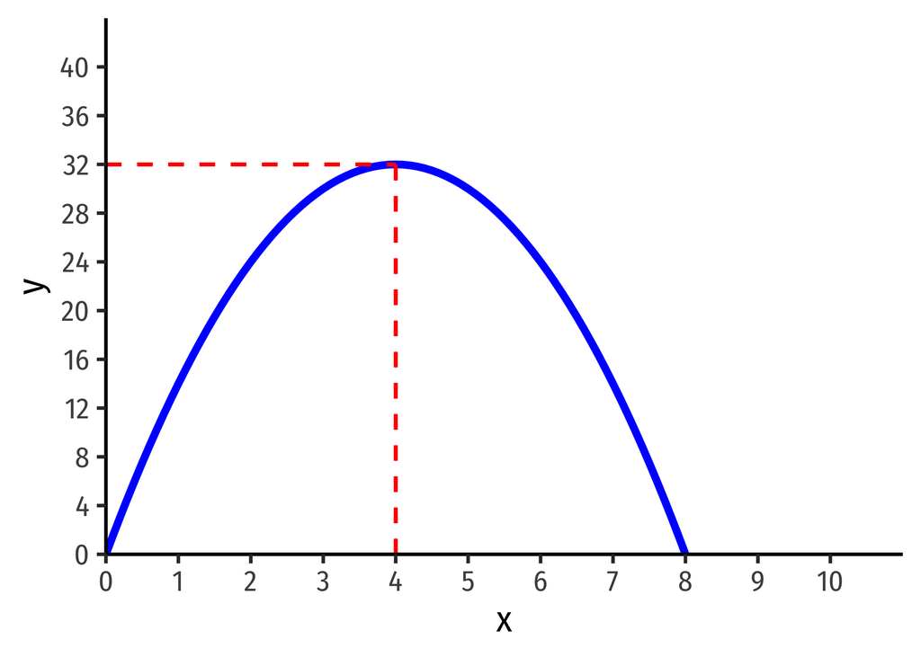

## 7

#### Explain what a tangency on a curve means. What is true about the tangent line?

A tangency point is where a curve and a line do not cross or intersect, but share a single point that is on both. At the point of tangency, both the curve and the line have the same slope (first derivative). This fact is useful in tracking the slope of a curve as it changes, since we can find the equation of the line tangent to the curve at any particular point.

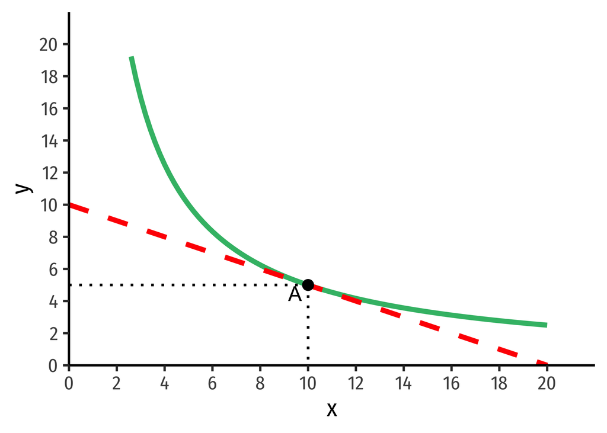

## 8

#### On a scale of 1 (worst) to 10 (best), rate your algebra skills (i.e. solving equations, graphing lines, working with fractions, etc.).

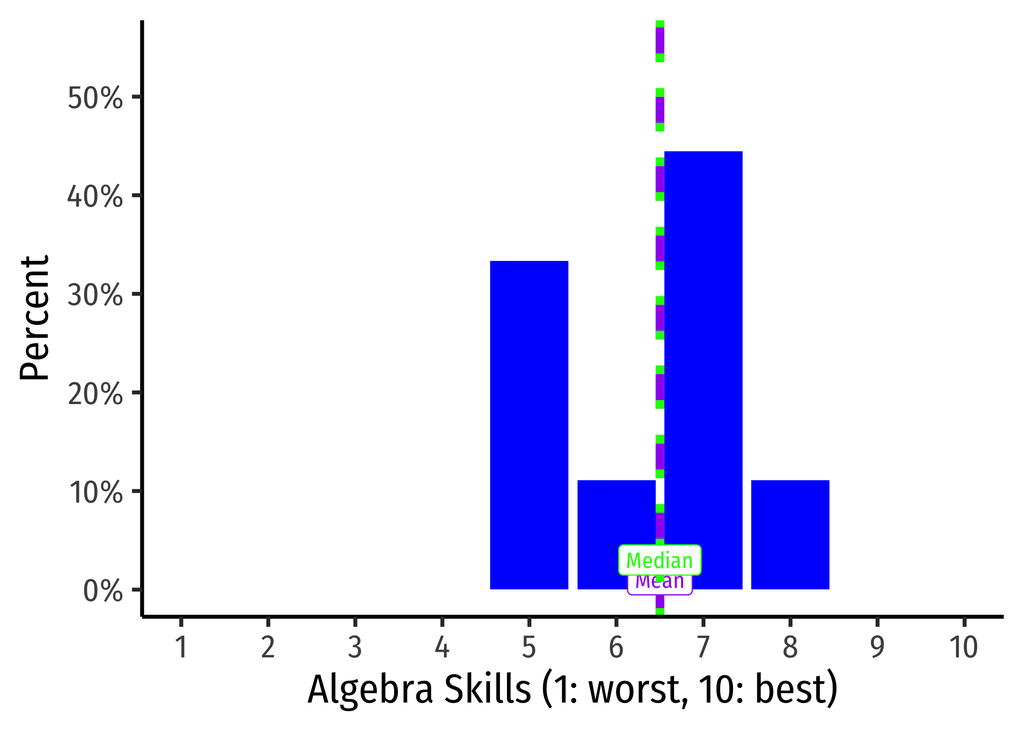

## 9

#### Have you had any experience with calculus?

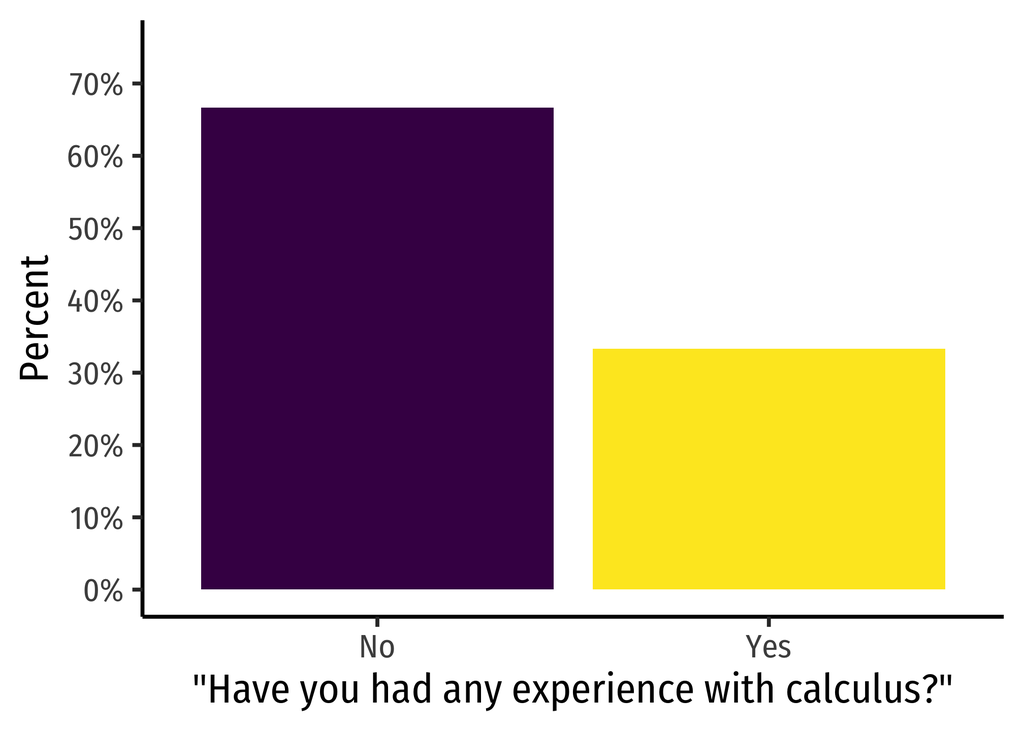

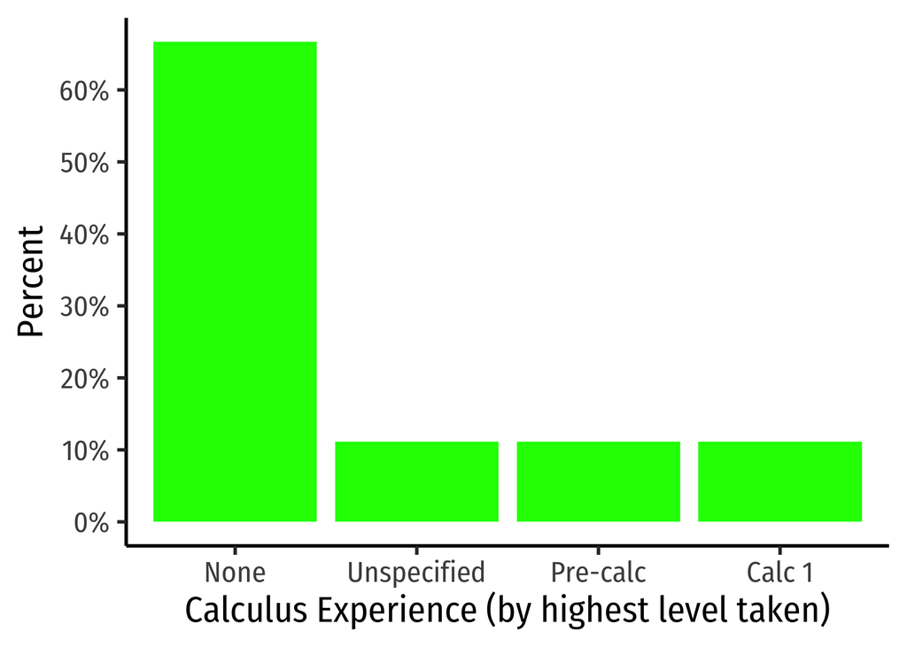

## 10

#### On a scale of 1 (least) to 10 (most), how anxious are you about this class? Feel free to elaborate any specific anxieties – it will make it more likely that I can speifically address them!

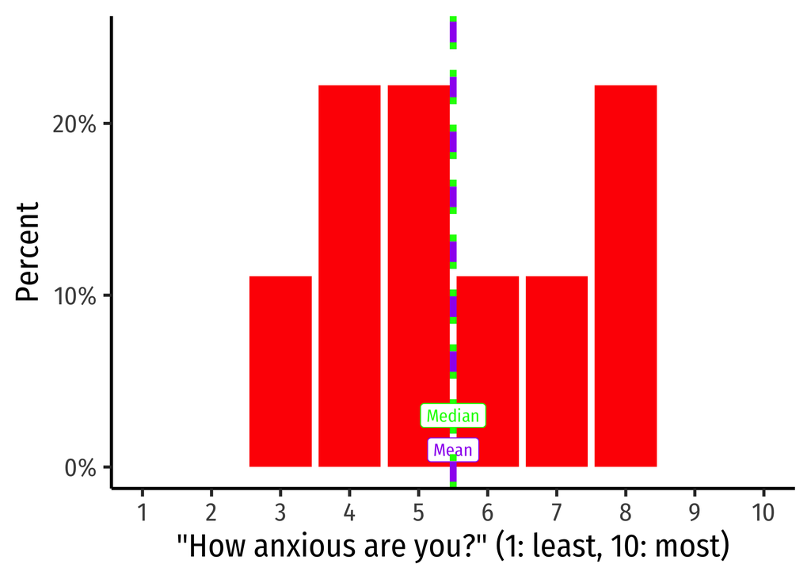